# Огород сентябрь 2023

2023-09-05

## Вопросы, которые меня интересовали

*Какому СУ (спецучастку гонки) надо было уделить больше времени на просмотре?

*Какой СУ сильнее влияет на итоговый результат?

*Каков мой результат относительно других участников?

# Исследуем время каждого спецучастка

## Описательные статистики

Переведем все времена в секунды, определим для каждого СУ минимальное и максимальное время проезда, а так же среднее значение, стандартное отклонение и медиану.

| name | min | max | mean | sd | median |
| --- | --- | --- | --- | --- | --- |
| СУ1 | 75.10 | 138.35 | 97.60 | 12.97 | 95.69 |
| СУ2 | 60.45 | 138.85 | 83.15 | 16.24 | 78.10 |
| СУ3 | 59.53 | 105.34 | 73.79 | 9.33 | 71.52 |
| СУ4 | 62.00 | 102.56 | 77.31 | 8.78 | 75.16 |
| СУ5 | 65.03 | 135.50 | 80.49 | 10.53 | 77.94 |
| СУ6 | 40.99 | 86.40 | 54.41 | 8.23 | 52.85 |

Самый быстрый 6 СУ, самый продолжительный 1-й. Посмотрим на показатель стандартного отклонения (sd). Он показывает, насколько в среднем отличались отдельные результаты от общего среднего (по всем участникам). Стандартное отклонение больше на 2-м СУ. Следующим по величине стандартного отклонения идет 1-й, и затем 5-й СУ. Это говорит о том, что именно эти спецучастки, в таком порядке сильнее всего влияли на итоговый результат. Ведь если всех велосипедистов запустить по прямой, их результаты будут отличаться не сильно, и навыки катания окажутся не важны. Соответственно, стандартное отклонение будет небольшим. Чем более требовательный спецучасток к технике, тем сильнее на нем будут различаться результаты разных по уровню велосипедистов. На 2-м СУ свою роль сыграли объезды вокруг гэпов, которые нельзя было преодолеть, не набрав достаточно скорости, для чего надо было уметь неплохо поворачивать. На 1-м СУ можно было оказаться в невыгодном положении, потеряв скорость перед подъемом. Ну а 5-й спецучасток был довольно-таки протяженным и крутильным. 6-й оказался и самым коротким, и самым простым.

# Гистограммы

Эти гистограммы показывают, сколько участников попали в каждый из 5-ти секундных временных отрезков, на которые разбиты все показанные участниками времена.

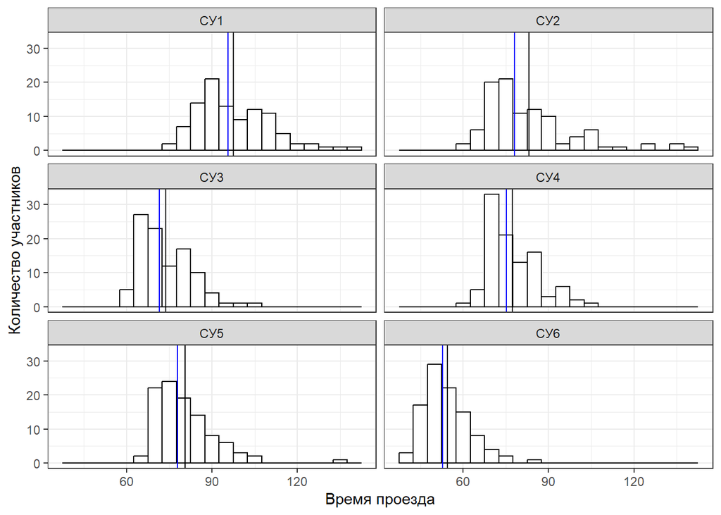

Тут интересно, что на 4-м СУ более 30 участников финишировали в 5-ти секундном интервале, а в следующем 5-ти секундном интервале разместились ещё 20 участников. То есть, практически результаты половины всех стартовавших уместились в 10 секундах. Интересно также, что никто из этих 30 не включился в борьбу за лидерство на СУ, 2-3 секунды отделяют лидеров этой группы от 3-го места на спецучастке. Для 1го спецучастка, например, характерно, наоборот, более плавное приближение к лучшему времени.

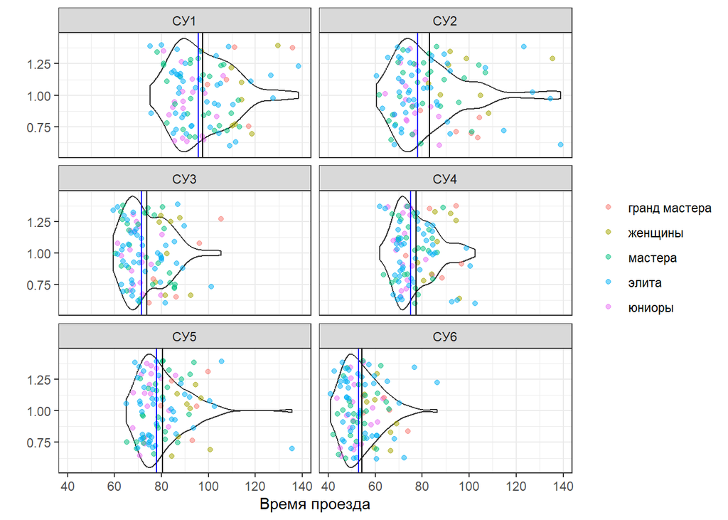

По этим графикам видно, что в медленном хвосте графика не так много участников, большая часть участников смещена к более быстрому хвосту. Значит, неопытные участники, которых было не очень много, сдвинули среднее, и как меру центральной тенденции лучше использовать медиану, которая делит всех участников на две равные части 50% быстрее и 50 % медленнее (показателя медианы). Поэтому синяя линия на графиках - медиана.

# Визуализируем итоговый результат по категориям

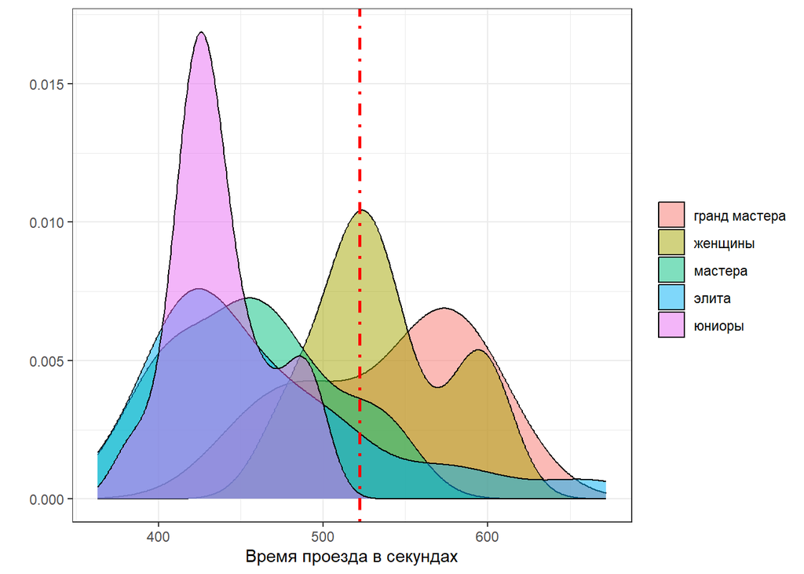

# Нормализуем данные, чтобы сравнивать проезды разных СУ

Так выглядят нормализованные данные. Распределение немного выровнялось, но все равно не симметрично, а растянуто вправо. Теперь для каждого СУ среднее значение это ноль.

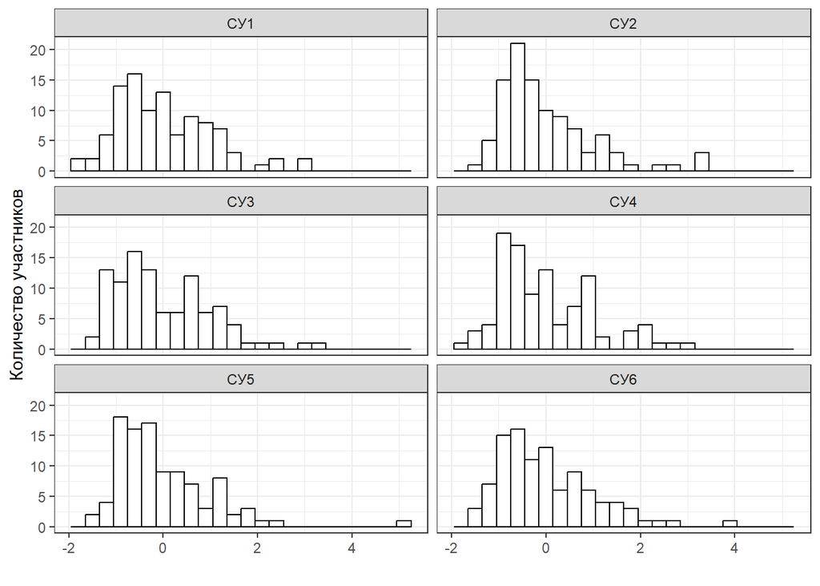

Если результат участника выше среднего (то есть быстрее), то значение результата отрицательное, если медленнее, то положительное.

Теперь сравним результаты отдельных участников. Я рассматриваю результаты в своей категории, благо, участниц в этот раз было восемь.

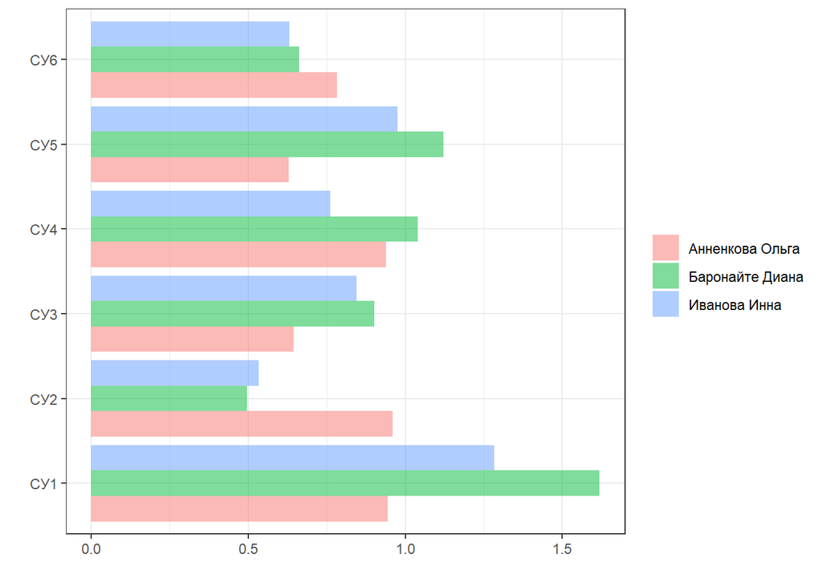

По графику видно, что проезды и мои, и Ольги, медленнее среднего, я существенно лажанула на 1-м СУ, Ольга проехала ровно 1, 2-й и 4-й. Лучше всего ей удались СУ 3 и СУ 5, что говорит о том, что она не боится крутильных участков, и даже они, скорее всего, ее сильная сторона. Мне лучше всего 2-й, ну на него я потратила и больше времени при просмотре (а надо было ещё и к первому отнестись повнимательнее). У Дианы явно не задался первый СУ, помню, она говорила, что ошиблась там, зато на 2 СУ обогнала и меня, и Ольгу, а говорила, что приехала за фоточками. Вот и верь после этого людям ))

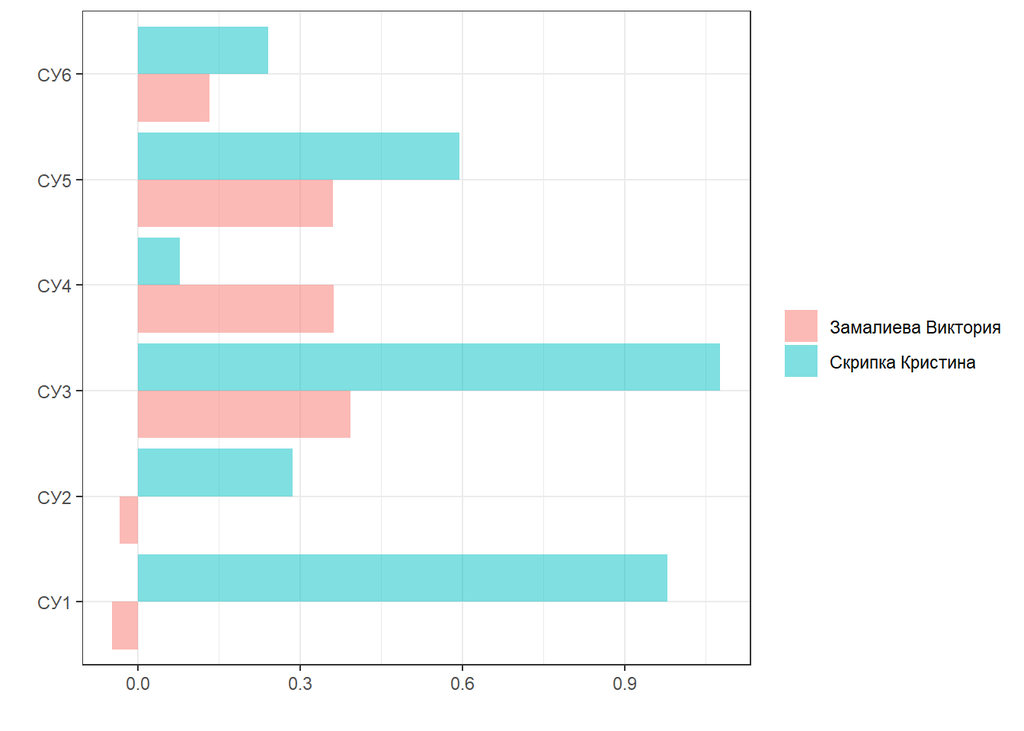

Вика хорошо, быстрее общего среднего проехала и 1-й и 2-й СУ. Остальные все медленнeе среднего, но всё равно стабильно и хорошо, особенно для новой местности. Кристина прям блеснула на 4-м, у нее лучшее время среди девушек, и 6-й был вполне неплох. 1-й и 3-й СУ дались Кристине сложнее. 5-й не вызвал таких сложностей, как 3-й, соответственно, дело скорее всего не в крутильных навыках, а, вероятно, в случайной ошибке.

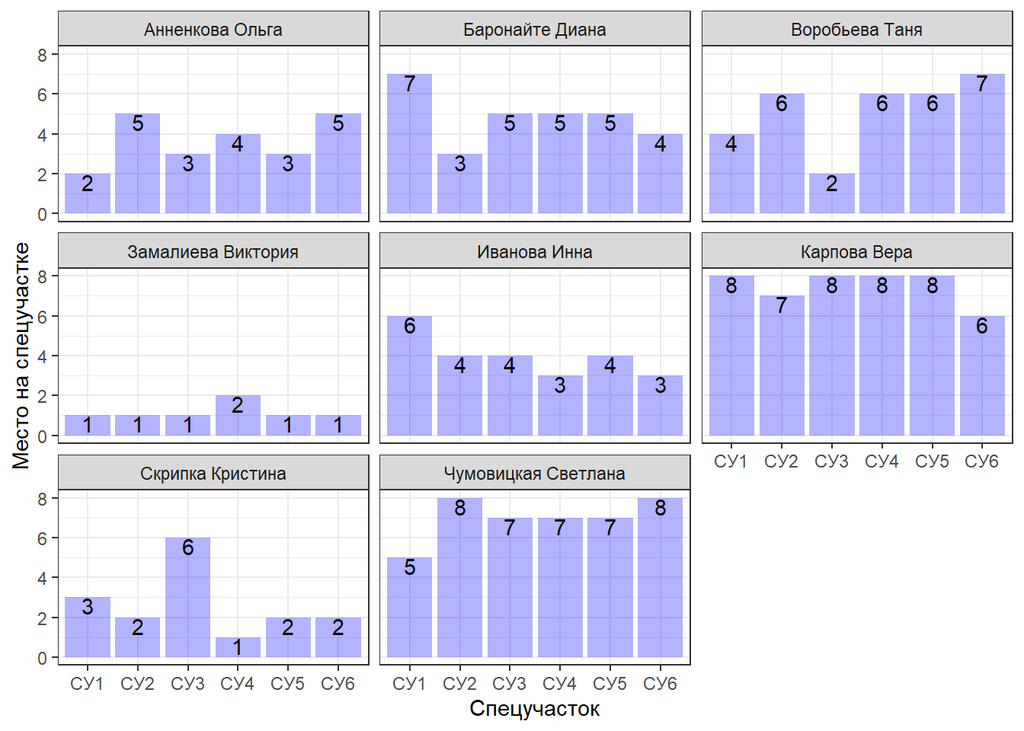

Характерно, что девушки на кантрийном стиле, Чумовицкая Светлана (на хардтейле) и Воробьева Татьяна хорошо (относительно меня) проехали 1-й СУ, а Воробьева Татьяна даже показала 2-е время среди всех девушек на 3-м СУ.

В заключение скажу, что гораздо приятней и интересней соревноваться, когда на соревнования заявляются участницы, причем с разным бэкграундом и происходит какая-то борьба.

[Здесь](https://enduro.shinyapps.io/app_2_5/) находится дашборд, который позволяет сопоставить результаты двух участников по спецучасткам в описанном выше стиле. Приложение должно работать 25 часов активного использования. Если будет нужно, смогу позже его переложить, чтобы дашборд оставался доступен большее количество времени.